# Prévalence de l’utilisation des méthodes contraceptives et analyse de ses déterminants sociodémographiques chez les femmes en âge de procréer en République Démocratique du Congo

djo kangoma

2025-09-07

Introduction

La santé reproductive est un enjeu majeur de santé publique dans le monde, en particulier en Afrique subsaharienne, où l’accès aux méthodes contraceptives demeure limité malgré les efforts internationaux. Selon l’Organisation mondiale de la Santé (OMS), l’utilisation des méthodes modernes de contraception contribue de manière significative à la réduction de la mortalité maternelle et infantile, à l’amélioration de la santé des femmes et au bien-être des familles. Elle favorise également le développement socio-économique en permettant aux femmes et aux couples de mieux planifier leurs naissances et de participer activement à la vie économique et sociale.

En République Démocratique du Congo (RDC), un pays caractérisé par une forte croissance démographique et une grande diversité socioculturelle, la prévalence contraceptive demeure relativement faible comparée à d’autres pays africains. Les données issues des enquêtes démographiques et de santé montrent de fortes disparités entre les provinces, entre les milieux urbains et ruraux, ainsi qu’entre les différents groupes sociodémographiques. Ces écarts peuvent être liés à des facteurs tels que l’âge, le niveau d’instruction, la religion, la situation matrimoniale ou encore le type de résidence.

L’utilisation des méthodes contraceptives est en effet influencée par des déterminants multiples, à la fois individuels (connaissances, âge, statut matrimonial), communautaires (normes culturelles, croyances religieuses) et structurels (disponibilité des services, politiques de santé). Comprendre ces déterminants constitue une étape essentielle pour orienter les politiques publiques et améliorer l’accès équitable à la contraception.

Dans ce contexte, la présente analyse a pour objectifs :

D’estimer la prévalence de l’utilisation des méthodes contraceptives chez les femmes en âge de procréer en RDC ;

De mettre en évidence les disparités géographiques et sociales afin de dégager des pistes d’action pour renforcer les programmes de planification familiale.

Cette étude se veut donc un outil d’aide à la décision en matière de santé reproductive, en mettant en lumière les facteurs qui favorisent ou freinent l’adoption des méthodes contraceptives dans le contexte congolais.

Objectifs de l’analyse :

Décrire les caractéristiques sociodémographiques des femmes en âge de procréer

Explorer les déterminants sociodémographiques (âge, instruction, résidence, province, mariage)

# Définition des variables utilisées

Définition des variables de l’analyse

| Variable | Description | Type |
| --- | --- | --- |
| age | Âge de la femme en années révolues | Quantitative continue |
| province | Province de résidence | Qualitative nominale |
| lieu_residence | Milieu de résidence (urbain/rural) | Qualitative binaire |
| niveau_instruction | Niveau d’instruction atteint | Qualitative ordinale |
| utilisation_type_methode | Type de méthode contraceptive utilisée | Qualitative nominale |
| situation_matrimoniale_actuelle | Statut matrimonial actuel | Qualitative nominale |

# 1. Distribution de l’âge

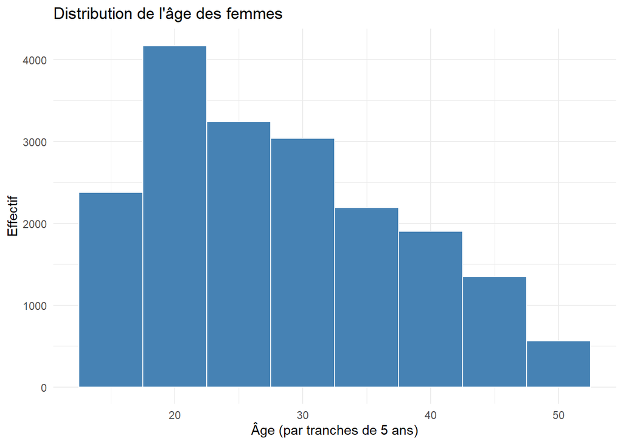

L’histogramme montre que la répartition de l’âge des femmes est concentrée dans certaines tranches, avec une plus forte représentation des jeunes adultes, tandis que les âges plus élevés sont moins fréquents.

# 2. Niveau d’instruction

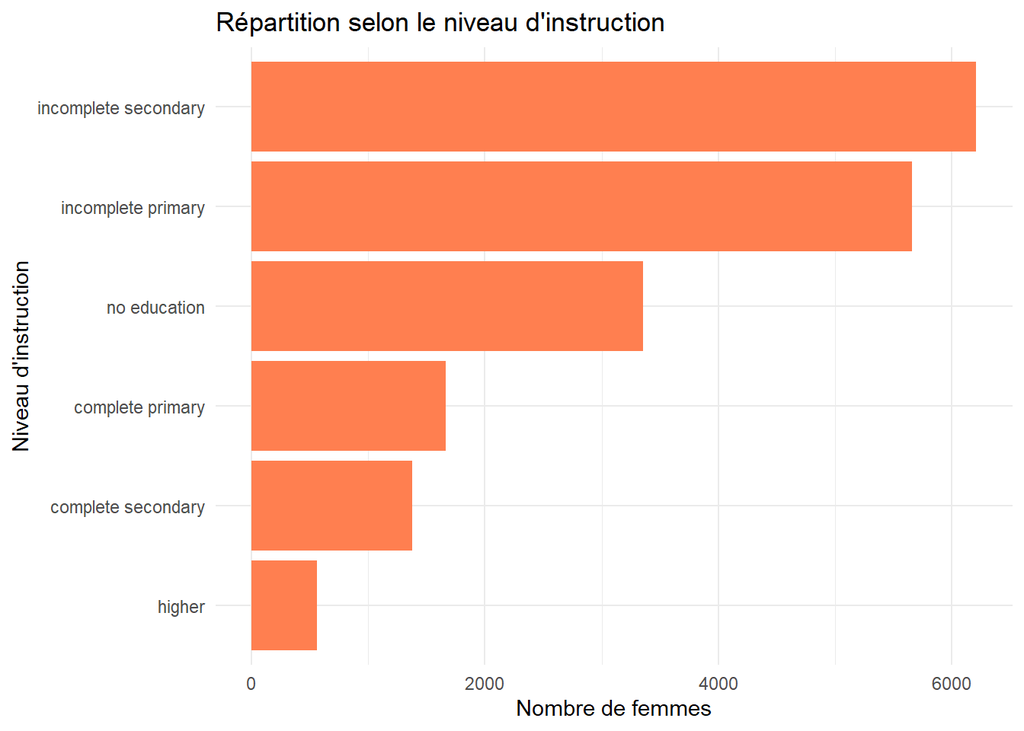

Le graphique montre une disparité selon le niveau d’instruction, avec une concentration plus importante dans certains niveaux (notamment l’enseignement primaire/secondaire), tandis que les niveaux supérieurs sont moins représentés.

# 3. Situation matrimoniale et contraception

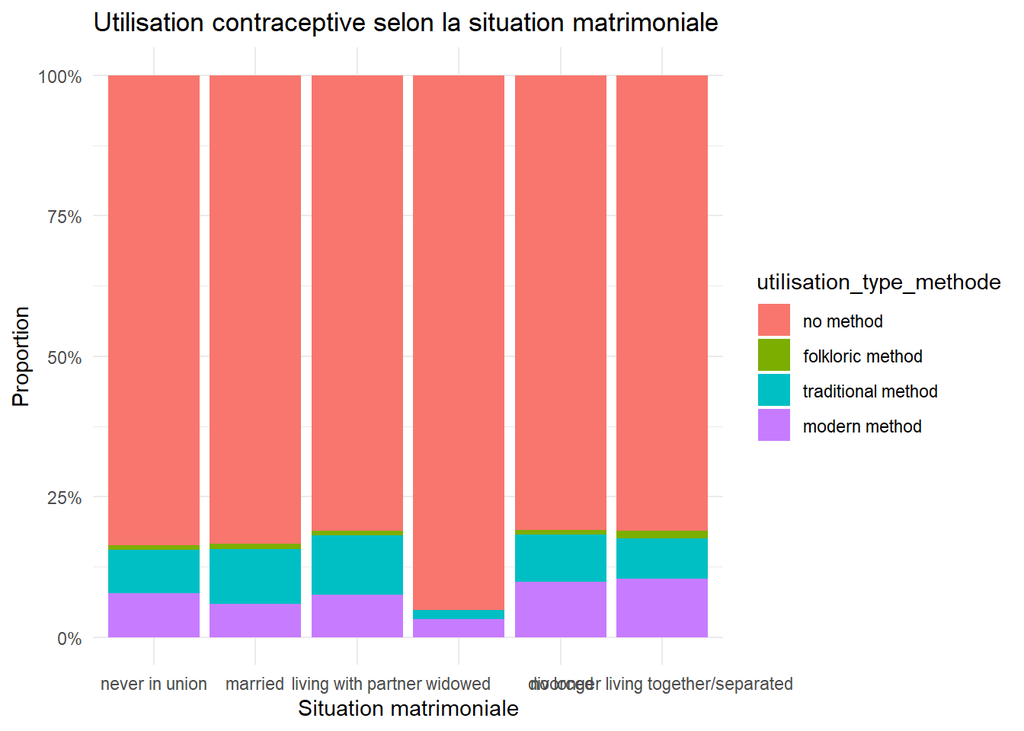

# 4. Prévalence contraceptive par province

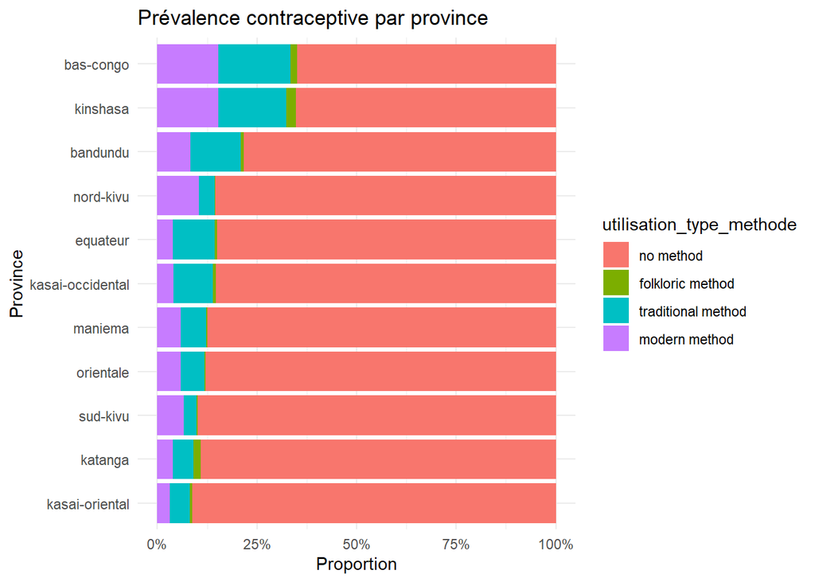

# 5. Distribution de l’âge par niveau d’instruction

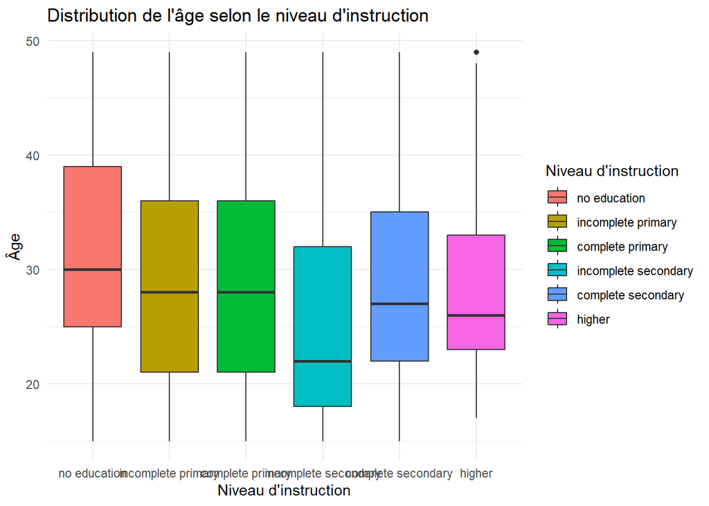

# Conclusion

Les analyses descriptives réalisées sur les données mettent en évidence plusieurs enseignements importants concernant la situation de l’utilisation contraceptive en République Démocratique du Congo (RDC).

Distribution de l’âge : la majorité des femmes enquêtées se situe dans la tranche de 20 à 35 ans, âge correspondant à une période de forte fécondité et donc de besoins accrus en matière de planification familiale. Ce constat rejoint les analyses de l’Enquête Démographique et de Santé en RDC (EDS-RDC, 2014) qui indiquent que les besoins non satisfaits en contraception sont les plus élevés dans ces groupes d’âge.

Niveau d’instruction : la répartition montre une concentration notable des femmes dans les catégories « primaire » et « secondaire », avec un faible pourcentage de femmes ayant atteint l’enseignement supérieur. Or, la littérature démontre que l’éducation est un déterminant majeur de l’utilisation contraceptive : les femmes instruites ont une meilleure connaissance des méthodes disponibles et une plus grande autonomie décisionnelle (Cleland et al., 2012 ; Bongaarts, 2017).

Prévalence par province : on observe une disparité géographique importante. Certaines provinces (souvent urbaines comme Kinshasa) affichent une adoption plus élevée, liée à une meilleure accessibilité des services de santé et à des campagnes de sensibilisation plus intensives, tandis que les provinces rurales restent en retrait. Cette hétérogénéité spatiale est documentée dans les rapports DHS et par May et al. (2017), qui insistent sur le rôle du contexte local dans l’accès aux services de planification familiale.